# 13 Hard Limits of Computation

Algorithmics 2025

# Origins of Computer Science

A History Lesson

## Vocabulary

- **Axiom** — foundational statement assumed true
- **Church–Turing thesis** — defines the boundary of what is computable
- **Completeness**
- **Computable** — can be solved by a Turing machine
- **Consistent** — no contradictions in the system
- **Decidable** — algorithm exists that always halts with yes/no

## Vocabulary

- **Entscheidungsproblem** - Ent-shy-dungs-problem - decision problem posed by Hilbert
- **Finite** — limited in size or length
- **Halting Problem** — classic undecidable problem
- **Paradox** — self-contradictory result (like Russell’s Paradox or the Liar Paradox)
- **Turing machine** — model of computation
- **Undecidable** — no such algorithm exists

## The Players

- **David Hilbert (1862–1943)**  
  German mathematician. University of Göttingen in Germany.
- **Wilhelm Ackermann (1896–1962)**  
  Student and collaborator of Hilbert. University of Göttingen in Germany.
- **Alonzo Church (1903–1995)**  
  American logician. Princeton University in the USA.
- **Alan Turing (1912–1954)**  
  British mathematician and founder of computer science. University of Cambridge (UK).  
  From 1936 to 1938, Turing went to Princeton to do his PhD under Alonzo Church.

## Timeline of Publications

- **1928**  
  **Hilbert and Ackermann**  
  *Grundzüge der theoretischen Logik* (*Principles of Mathematical Logic*).  
  They formalised first-order logic and clearly defined the **Entscheidungsproblem** (decision problem): whether there exists a general mechanical procedure (algorithm) to decide if any given statement is provable.

## Timeline of Publications

- **1936**  
  **Alonzo Church**  
  *“An Unsolvable Problem of Elementary Number Theory”* published.  
  Church used **lambda calculus** to prove that the **Entscheidungsproblem** is undecidable — showing that there is no general algorithm to decide provability for all statements in first-order logic.

## Timeline of Publications

- **1936**  
  **Alan Turing**  
  *“On Computable Numbers, with an Application to the Entscheidungsproblem”* published.  
  Turing introduced the **Turing machine** as a new model of computation.  
  He proved the **Halting Problem** is undecidable, which implies that the **Entscheidungsproblem** is undecidable too.

## The Story

- In the early 20th century, mathematics faced a crisis due to logical paradoxes, such as Russell’s Paradox.

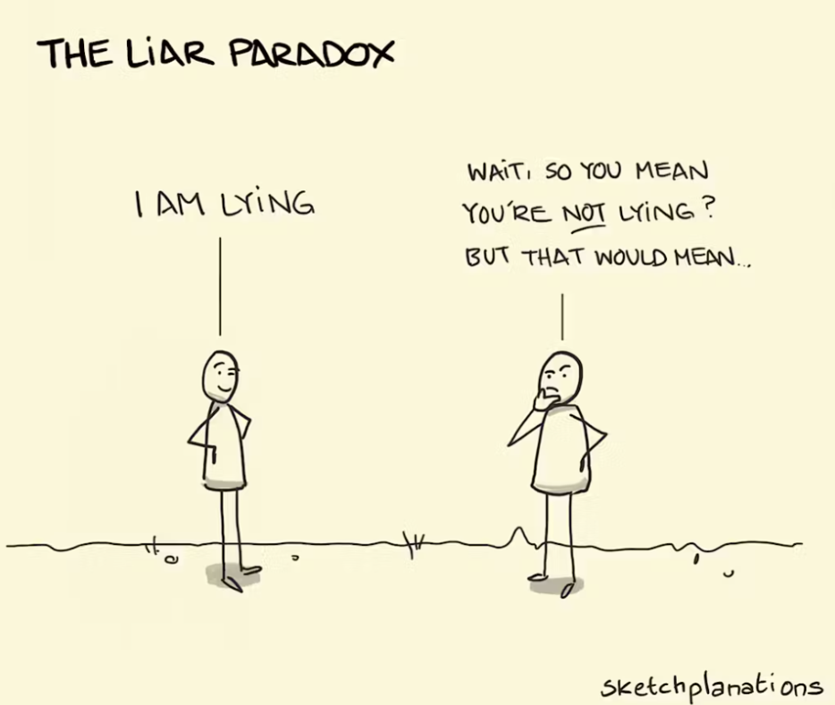

- Hilbert proposed a solution: formalise all of mathematics using a set of axioms and rules. His goal was a symbolic system in which all mathematical truths could be derived mechanically — no intuition, just logic.

## The Story

- Ackermann worked with Hilbert to formalise logic and pose the Entscheidungsproblem: to find a single algorithm that could decide if a mathematical statement was true or false.
- In 1936, Alonzo Church proved that the Entscheidungsproblem is undecidable, using a formal model of computation called **lambda calculus**.

## The Story

- Around the same time, Alan Turing independently proved the same result using his new model of computation — the **Turing machine** — by showing that the **Halting Problem** is undecidable.
- Church and Turing’s work led to the formulation of the **Church–Turing Thesis**, the formal limit of what can be computed.

## Some Details

### Hilbert’s Program

Hilbert’s program aimed to reduce all of mathematics to formal symbolic manipulations.

Every line follows strictly from axioms and rules:

- No intuition, no diagrams, no external meanings.
- Just symbols and logic.

### Hilbert’s Program

In his 1927 program to fully formalise mathematical reasoning, David Hilbert outlined the following three goals:

1. Mathematics should be **complete**: all true mathematical statements can be derived from a finite set of axioms.
2. Mathematics should be **consistent**: no contradictions.
3. Mathematics should be **decidable**: proofs can be verified by a single algorithm.

## Classic physics as Example

- The finite set of axioms: **Newton’s three laws of motion** and the **Law of Universal Gravitation**.

**Key equations:**

$$\text{Newton's Second Law:} \quad F = ma$$

$$\text{Law of Universal Gravitation:} \quad F = G \frac{m_1 m_2}{r^2}$$

## Classic physics as Example

From just these axioms, you can:

- Predict the orbit of Earth around the Sun (Kepler’s laws).
- Calculate the trajectory of a rocket.
- Explain phenomena like tides.

## Classic physics as Example

The laws act like a formal system:

- They are **finite** (a few basic laws).
- They are **consistent** (no contradictions).
- They are **decidable** for simple systems (you can solve the equations exactly).

## Where Limits Appear

However, as systems become more complex:

- Many-body problems become chaotic.
- Exact solutions may be impossible; only approximations exist.
- Quantum mechanics introduces inherent uncertainty.

## Entscheidungsproblem

The **Entscheidungsproblem** posed by Hilbert and Ackermann challenged mathematicians to solve the third goal:

> Is there a general algorithm that can decide, for any mathematical statement, whether it is provable from the axioms?

In 1936, Alan Turing answered this question by proving that the **Halting Problem** is undecidable.

This serves as a **counterexample to Hilbert’s Goal 3**

## The Halting Problem

Turing developed the **Turing machine** to demonstrate the Halting Problem.

> The Halting Problem is to decide whether a given program with a given input halts or loops forever.
- If a math statement can be written as a sequence of logical steps, then this is equivalent to a program running on a Turing machine.

## The Halting Problem

**Assumption** Suppose there exists an algorithm `H` that always solves this problem.

```
H(program, input):
    if program(input) will loop forever:
        return "loops forever"
    else:
        return "halts"
```

```
Paradox(program):
    if H(program, program) == "loops forever":
        return "halts"
    else:
        while True:
            do nothing    # loops forever
```

```
Hello():
    print("hello world")
```

```
Not_a_paradox():
    while True:
        print("hello world")
```

## Evaluating `Paradox(Hello)`

1. `Paradox(Hello)` calls `H(Hello, Hello)`
2. `H(Hello, Hello)` evaluates to **“halts”**
3. Therefore, `Paradox(Hello)` actually **loops forever**

## Evaluating `Paradox(Not_a_paradox)`

1. `Paradox(Not_a_paradox)` calls `H(Not_a_paradox, Not_a_paradox)`
2. `H(Not_a_paradox, Not_a_paradox)` evaluates to **“loops forever”**
3. Therefore, `Paradox(Not_a_paradox)` actually **halts**

## Evaluating `Paradox(Paradox)`

1. `Paradox(Paradox)` calls `H(Paradox, Paradox)`
2. Two possibilities:
   - If `H` returns **“halts”** → `Paradox(Paradox)` loops forever → `H` was wrong.
   - If `H` returns **“loops forever”** → `Paradox(Paradox)` halts → `H` was wrong.
- **Conclusion:** This contradiction shows that `H` cannot exist, and therefore the **Halting Problem** is undecidable.